# Exploring Red Wine Quality Analysis by Sakshi Dubey

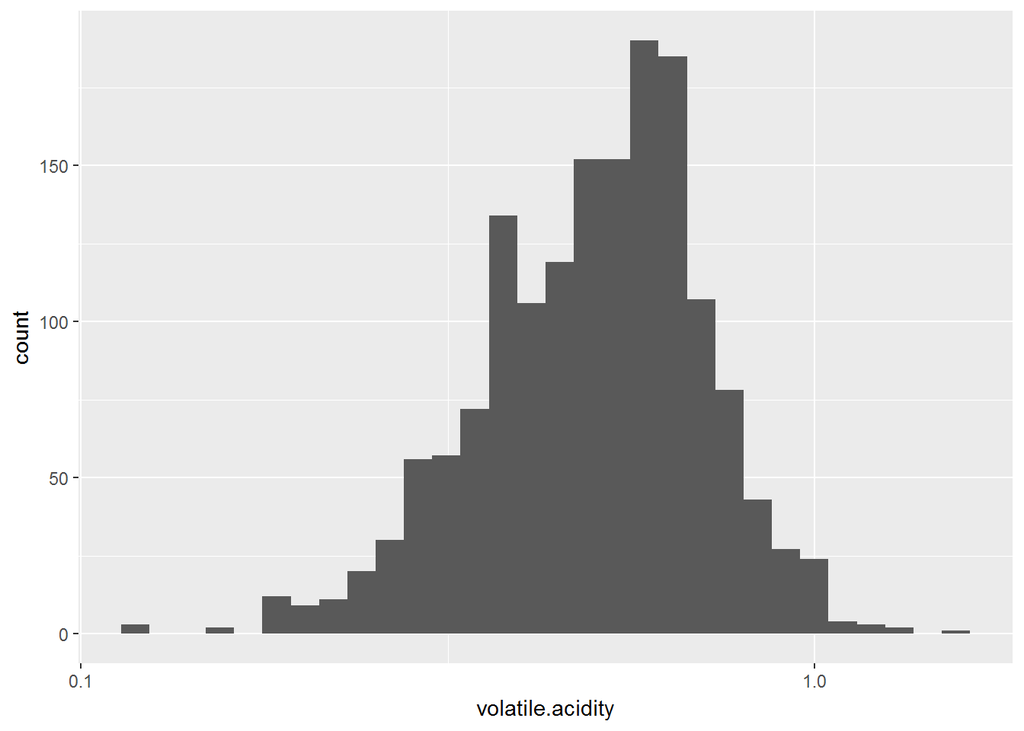

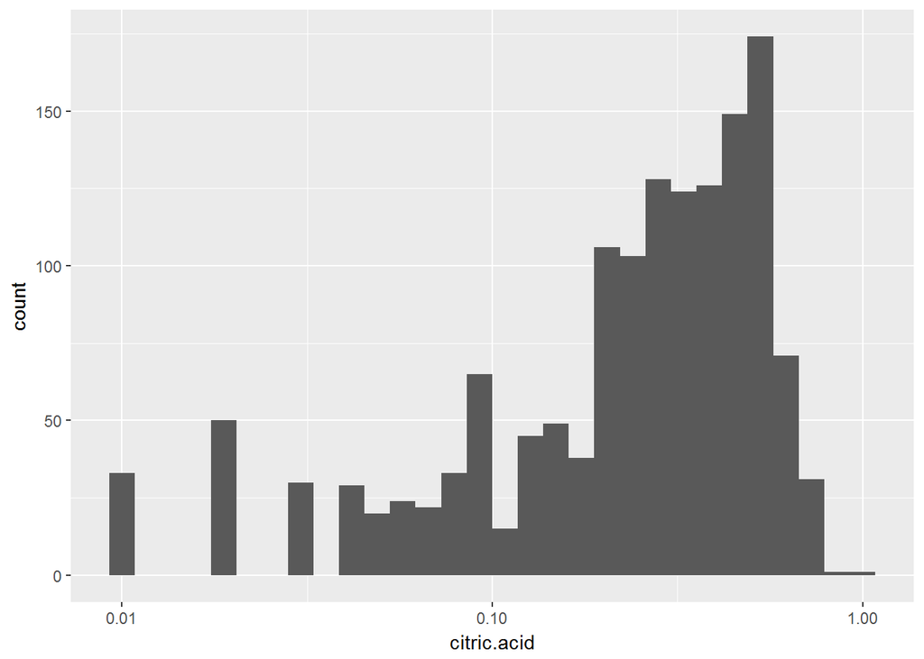

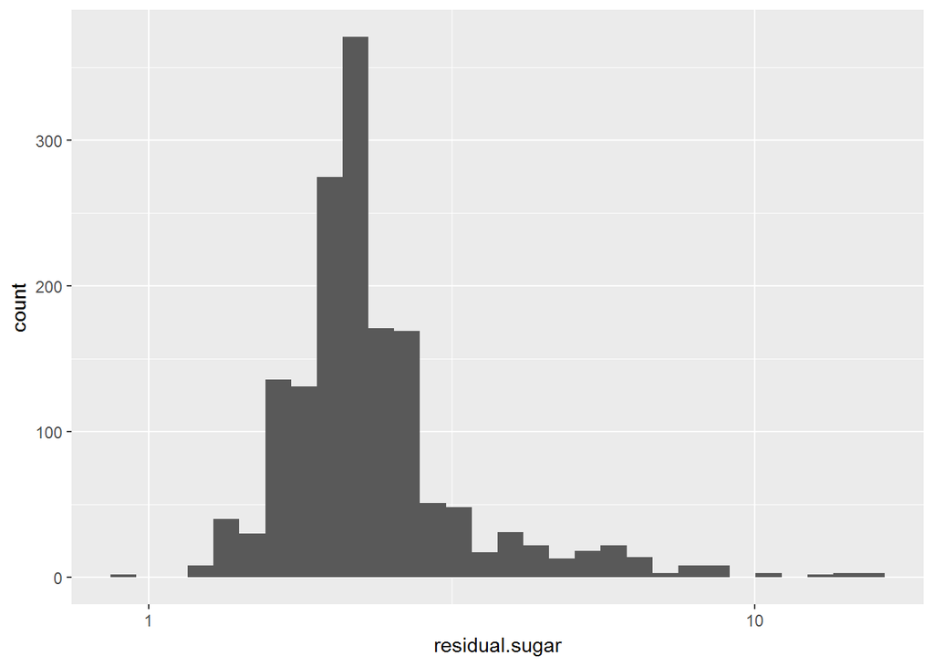

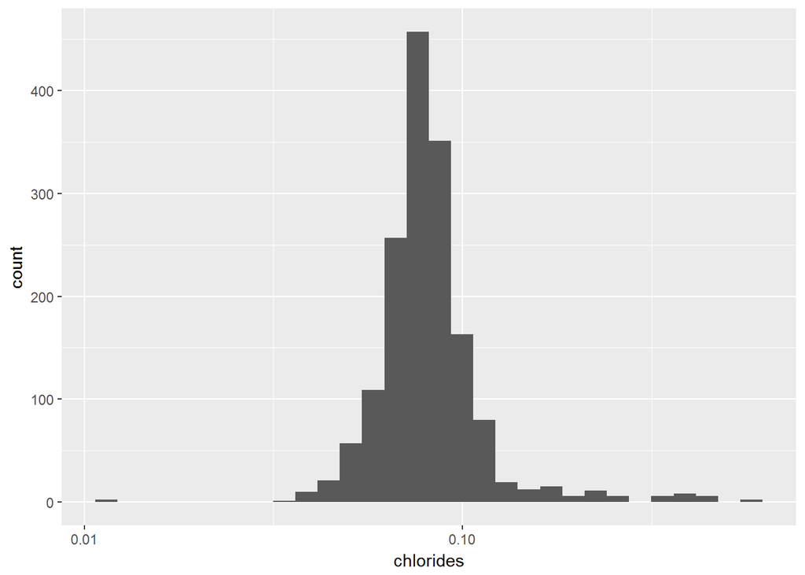

I have plotted all the graphs which I saw as consisting of outliers. From here we can differentiate that chlorides and residual.sugar have extreme outliers.

When I plotted the graphs on log10 scale, I observed that fixed.acidity and volatile.acidity appear to be normally distributed. So, considering that pH is normally distributed and pH by definition is a measure of acidity and is on the log scale.

As we can see citric.acid did not appear to be normally distributed on the log scale.

Now moving further:

```
## [1] 132
```

We can see that 132 observations had a value of 0. This yields some concerns that whether or not these 132 values were reported or not, considering that the next bin higher contains only 32 observations.

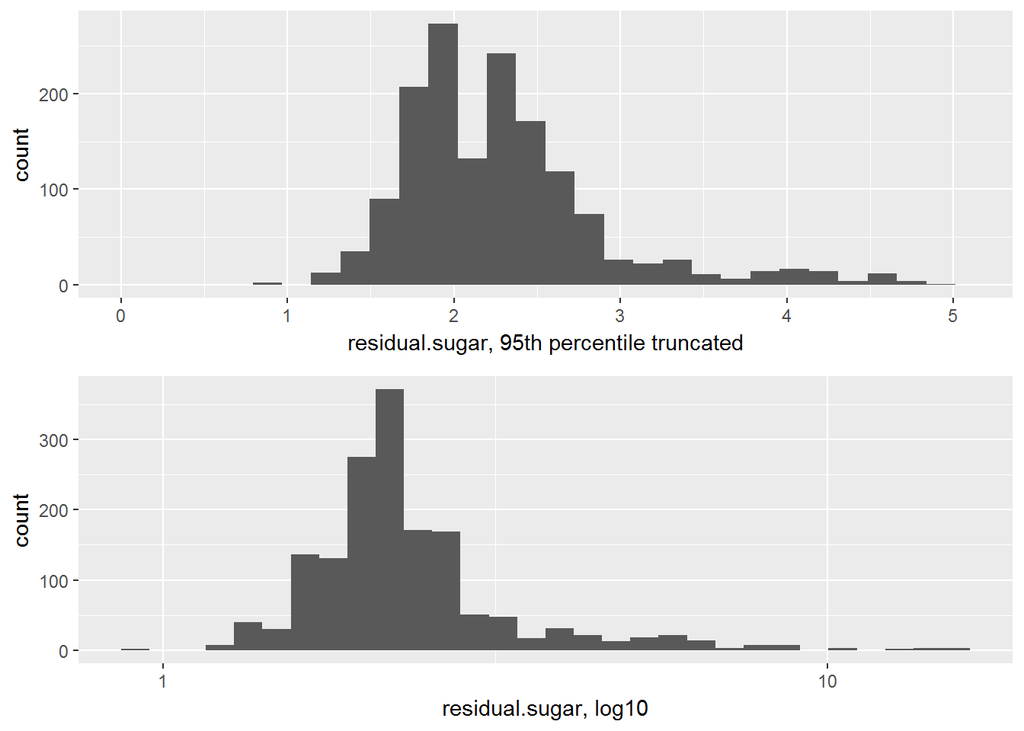

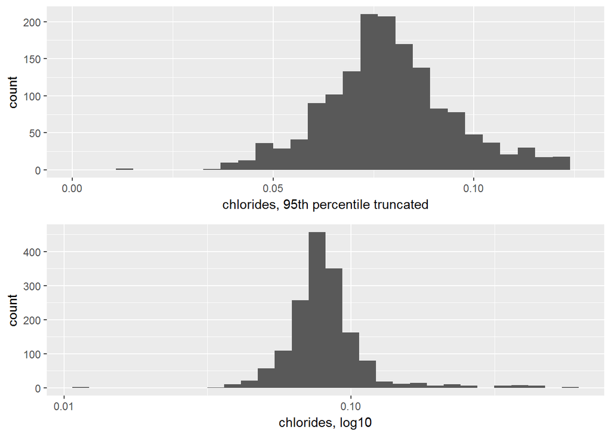

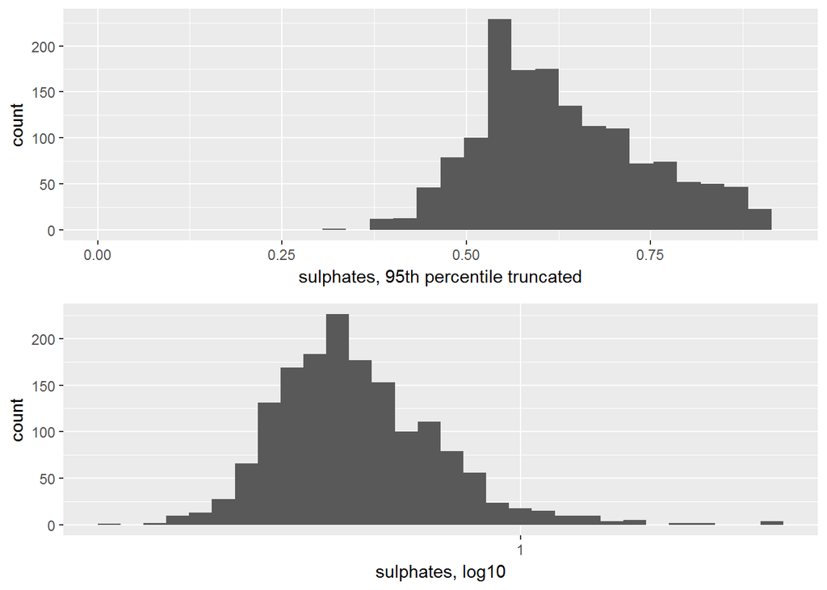

Now we will answer some questions on univariate analysis.

### What is the structure of your dataset?

There are 1,599 red wines in the dataset with 11 features on the chemical properties of the wine. ( fixed.acidity, volatile.acidity, citric.acid, residual.sugar, chlorides, free.sulfur.dioxide, total.sulfur.dioxide, density, pH, sulphates, alcohol, and quality).

### What is/are the main feature(s) of interest in your dataset?

The main features of interest in the dataset are pH and quality. I’d like to determine which features are best for predicting the quality of a wine.

### What other features in the dataset do you think will help support your investigation into your feature(s) of interest?

While exploring the univariate histogram distributions, there did not appear to be any bimodal or multimodal distributions that would warrant sub-classification into categorical variables. I considered potentially splitting residual.sugar into ‘sweet wine’ and ‘dry wine’, but as I searched on the internet I found that a residual sugar of greater than 45 g/L or g/m^3 to classify as a sweet wine.

### Did you create any new variables from existing variables in the dataset?

Yes, definitely I created an ordered **factor** rating, classifying the wine sample as bad, average and good.

On further analysis I found that fixed.acidity and volatile.acidity are different types of acids; tartaric acid and acetic acid.I decided to create a combined variable, TAC.acidity, containing the sum of tartaric, acetic, and citric acid.

We can look at the observations below:

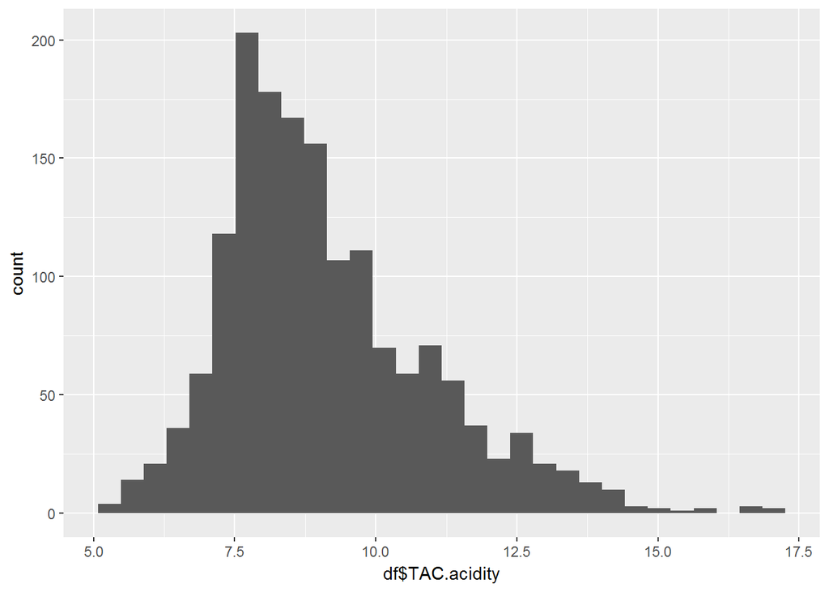

### Of the features you investigated, were there any unusual distributions? Did you perform any operations on the data to tidy, adjust, or change the form of the data? If so, why did you do this?

Although histogram are not good to plot in case of outliers so I decided to plot the boxplots which are better suited in visualizing the ouliers.

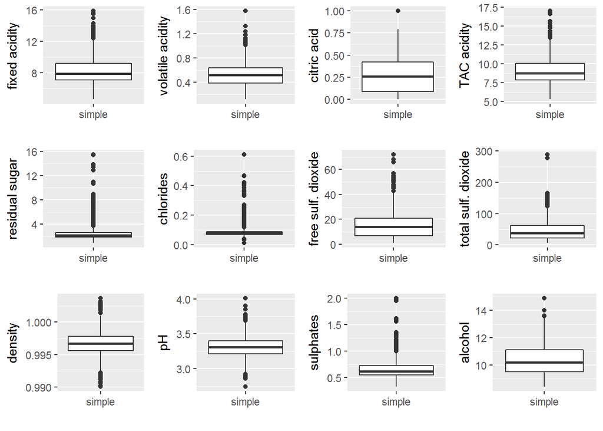

In univariate analysis, I chose not to tidy or adjust any data, short of plotting a select few on log scales. Bivariate boxplots, with X as rating or quality, will be more interesting in showing trends with wine quality.

# Bivariate Plots Section and Bivariate Analysis

To the understand more about how variables affect the quality, I plotted boxplots for each. We all know that boxplots are very helpful in finding quartile ranges.

Now look at the interesting observations.

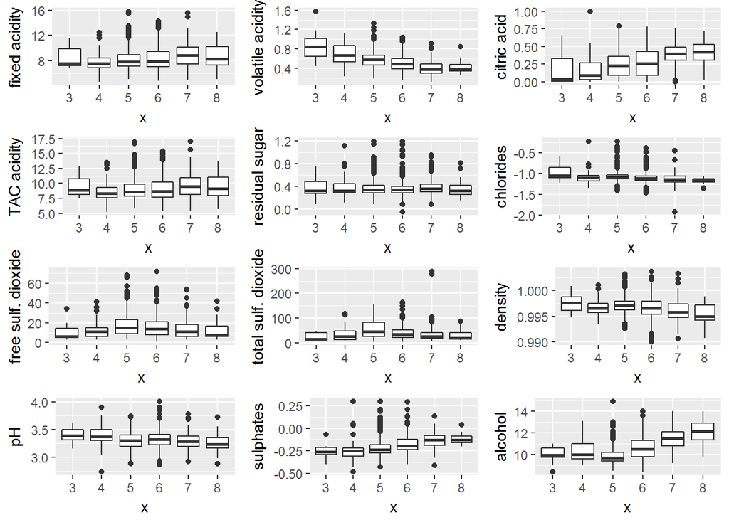

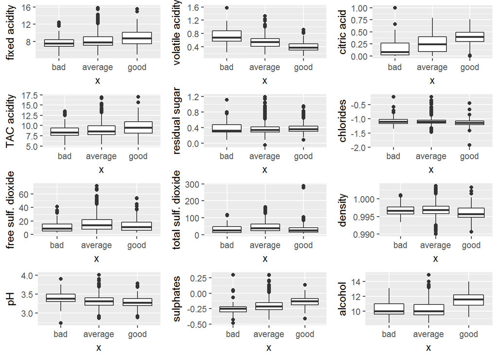

From exploring the above results we can see that ‘good’ wine has following trend:

- higher fixed acidity (tartaric acid) and citric acid, lower volatile acidity (acetic acid)
- higher alcohol
- higher sulphates
- lower pH (i.e. more acidic)
- to a lesser extend, lower chlorides and lower density

Residual sugar and sulphur dioxides did not seem to have large impact on the quality or rating of red wine.It appears that different types of acid affect wine quality different; as such, TAC.acidity saw an attenuated trend, as the presence of volatile (acetic) acid accompanied decreased quality.

Here I have used cor.test, I have calculated the correlation for each of these variables against quality.

```
##        fixed.acidity     volatile.acidity          citric.acid
##           0.12405165          -0.39055778           0.22637251
##          TAC.acidity log10.residual.sugar      log10.chlordies
##           0.10375373           0.02353331          -0.17613996
##  free.sulfur.dioxide total.sulfur.dioxide              density
##          -0.05065606          -0.18510029          -0.17491923
##                   pH      log10.sulphates              alcohol
##          -0.05773139           0.30864193           0.47616632
```

From the result obtained from above we can see that some of the variables have quite higher correlations to wine quality.

- alcohol
- sulphates(log10)
- citric acid
- volatile acidity

Now look at the following graphs, how these variables are compared and plotted against each other and faceted by wine rating.

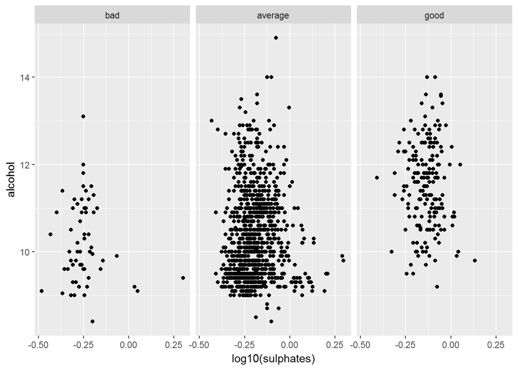

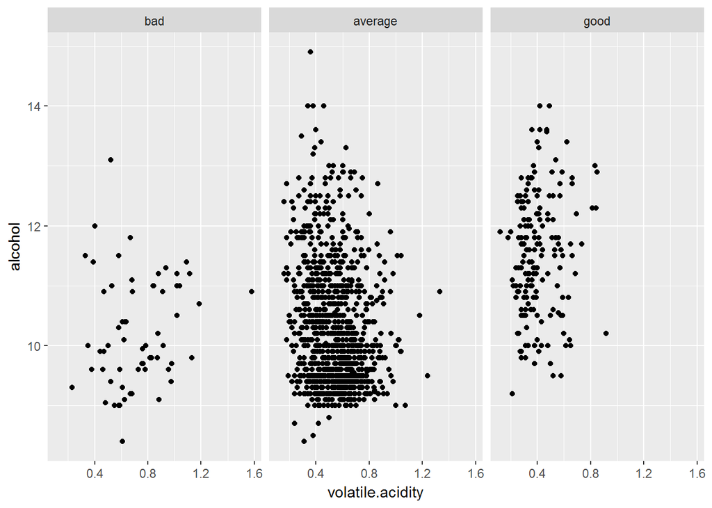

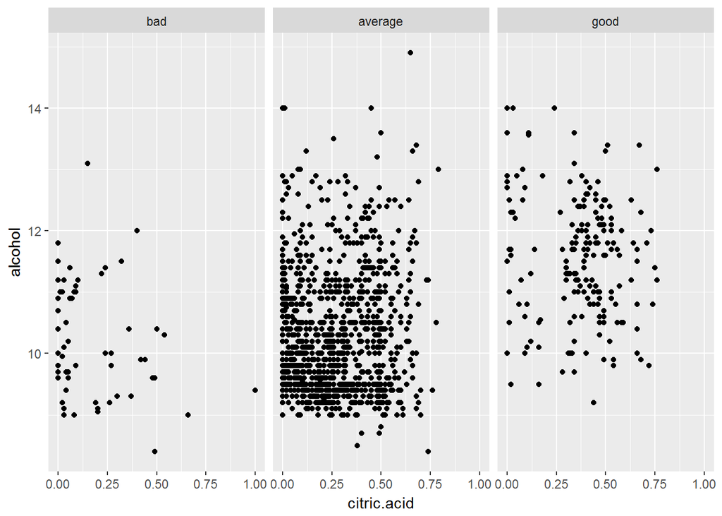

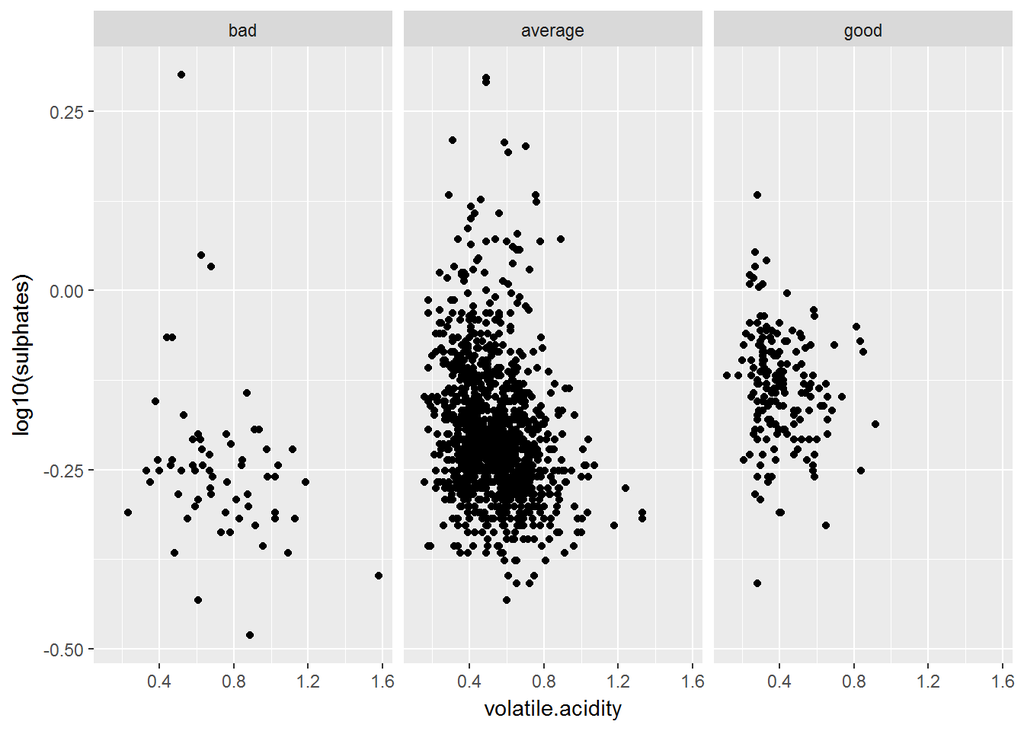

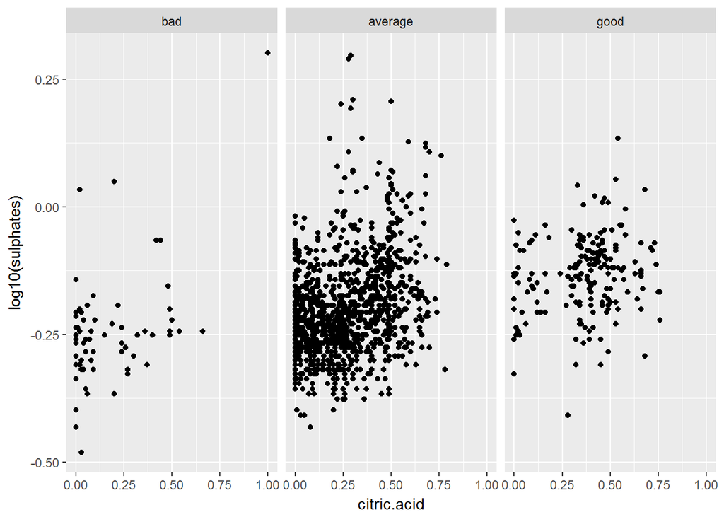

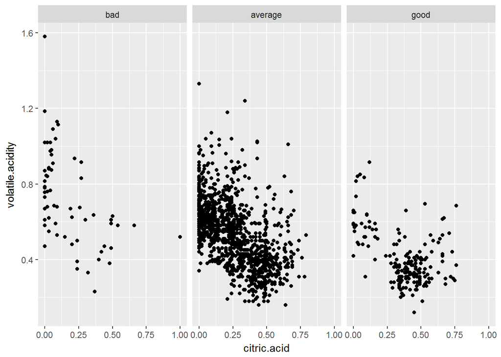

The above scatterplots indicates that how heavily alcohol content affects rating.The weakest bivariate relationship appeared to be alcohol vs. citric acid.The plots were nearly uniformly-distributed. The strongest relationship appeared to be volatile acididty vs. citric acid, which had a negative correlation.

When I examined the acidity variables, I found strong correlations between them.

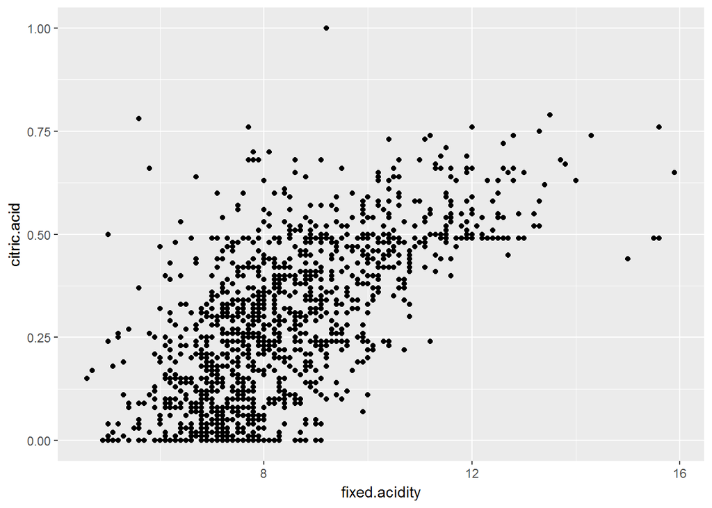

```
##
##  Pearson's product-moment correlation
##
## data:  df$fixed.acidity and df$citric.acid
## t = 36.234, df = 1597, p-value < 2.2e-16
## alternative hypothesis: true correlation is not equal to 0
## 95 percent confidence interval:
##  0.6438839 0.6977493
## sample estimates:
##       cor
## 0.6717034
```

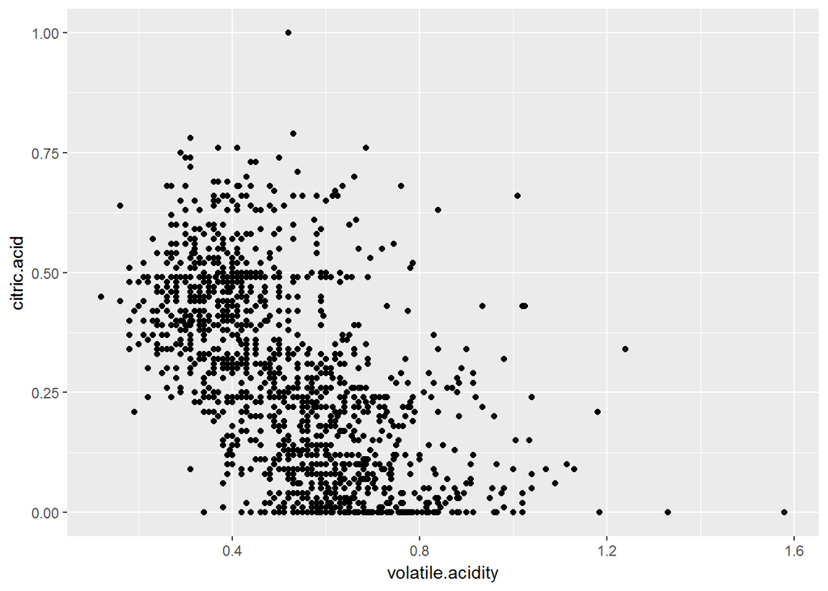

```
##
##  Pearson's product-moment correlation
##
## data:  df$volatile.acidity and df$citric.acid
## t = -26.489, df = 1597, p-value < 2.2e-16
## alternative hypothesis: true correlation is not equal to 0
## 95 percent confidence interval:
##  -0.5856550 -0.5174902
## sample estimates:
##        cor
## -0.5524957
```

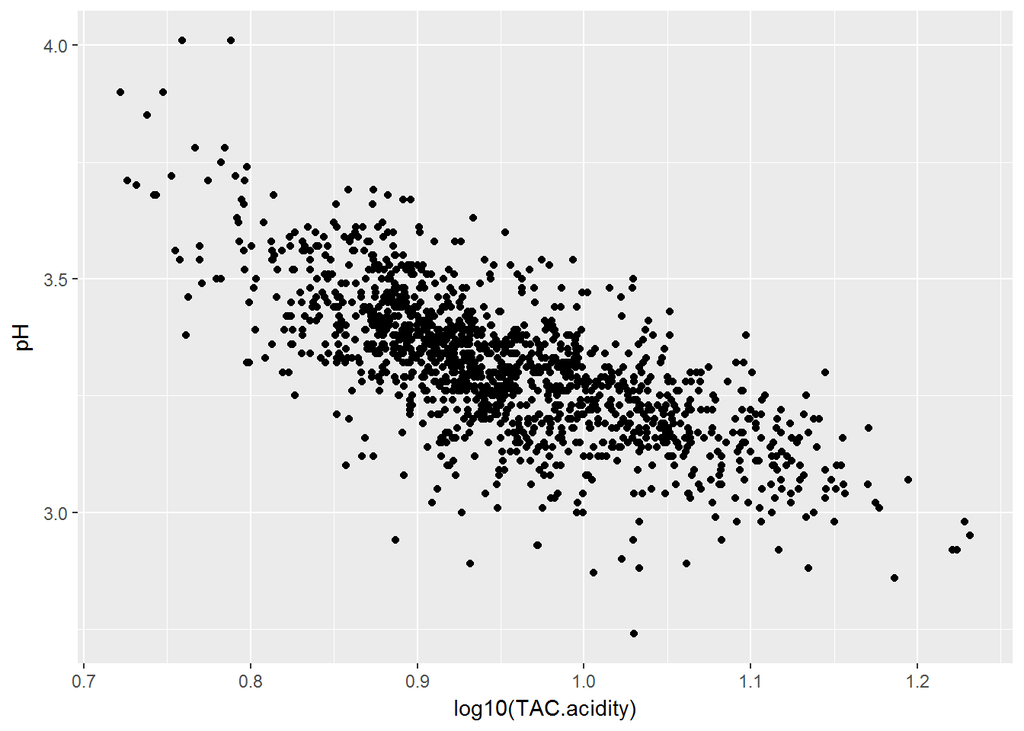

```
##
##  Pearson's product-moment correlation
##
## data:  log10(df$TAC.acidity) and df$pH
## t = -39.663, df = 1597, p-value < 2.2e-16
## alternative hypothesis: true correlation is not equal to 0
## 95 percent confidence interval:
##  -0.7283140 -0.6788653
## sample estimates:
##        cor
## -0.7044435
```

In the above agraphs I have used log base 10 scales. We can see that how **TAC.acidity** is nicely correlated with pH. This is what I expected because we all know that pH is a measure of acidity.

As we all know little bit about chemistry, I would like to raise an interesting question that, what are the other components other than measuring acids are affecting pH. In order to answer this question one way is that we can quantify this difference by building a predictive linear model, to predict pH based off of TAC.acidity and capture the % difference as a new variable..

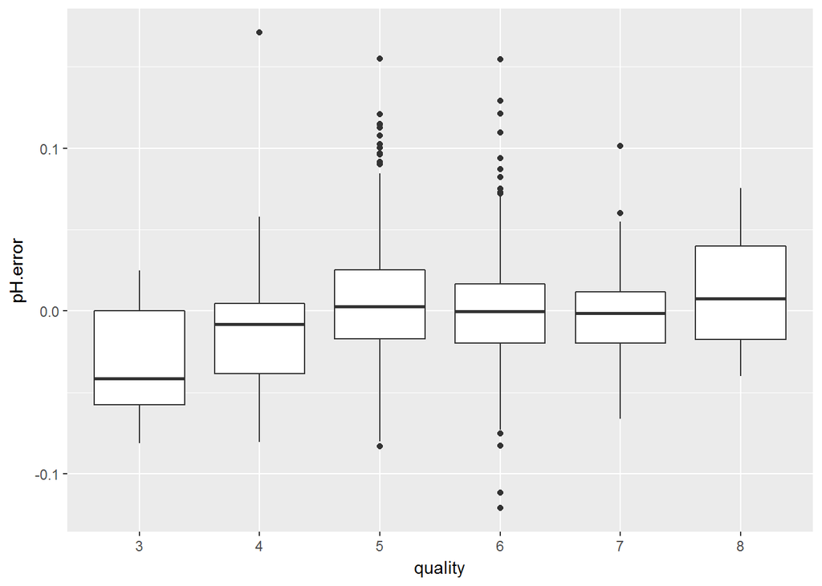

As we can see that median percentage error is hovered at or near zero for most wine qualities. As we have seen before as compared to 5 or 6 rating, 3 rating wines are less, but these wines(rated with 3) produced large negative error.

We can also say that for many of the ‘bad’ wines, total acidity from tartaric, acetic, and citric acids were a worse predictor of pH. It is likely that there were other components–possibly impurities–that changed and affected the pH.

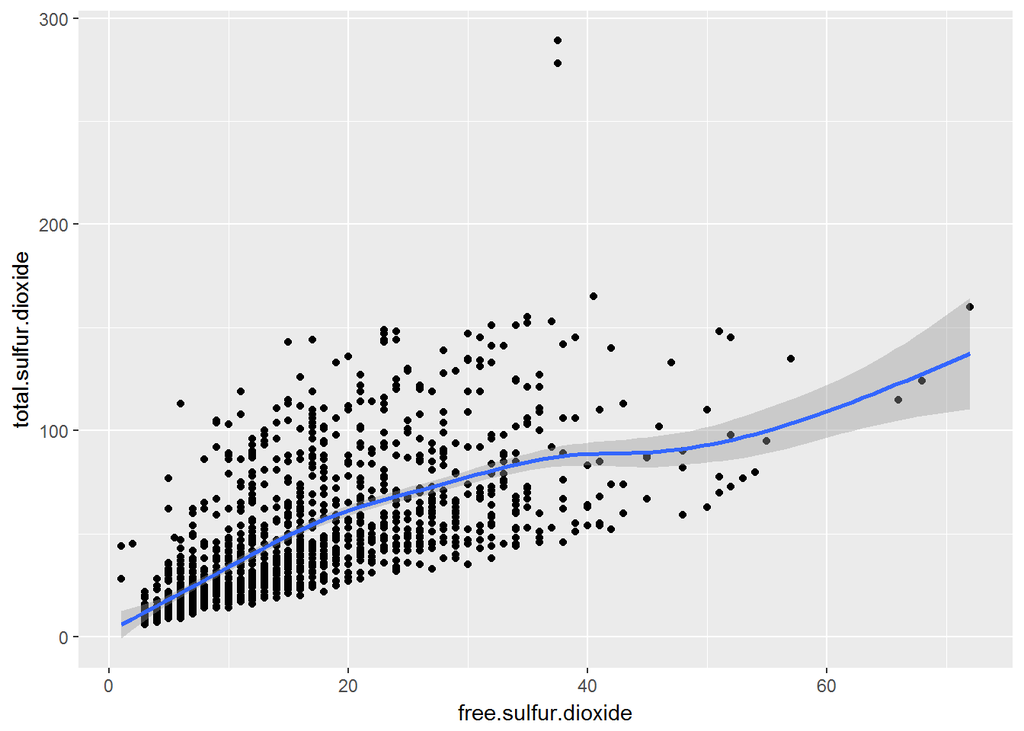

```
##
##  Pearson's product-moment correlation
##
## data:  df$free.sulfur.dioxide and df$total.sulfur.dioxide
## t = 35.84, df = 1597, p-value < 2.2e-16
## alternative hypothesis: true correlation is not equal to 0
## 95 percent confidence interval:
##  0.6395786 0.6939740
## sample estimates:
##       cor
## 0.6676665
```

### Talk about some of the relationships you observed in this part of the investigation. How did the feature(s) of interest vary with other features in the dataset?

I observed a negative relationships between quality level and volatile acidity, and positive correlation between quality level and alcohol. High volatile acidity is also perceived to be undesirable because it impacts the taste of wines. Alcohol and volatile acidity don’t have any clear relationship between each other.

### Did you observe any interesting relationships between the other features (not the main feature(s) of interest)?

Yes, I observed positive relationship between density and fixed acidity, positive relationship between fixed acidity and citric acid, and negative relationship between pH and fixed acidity. Other variables either show very weak relationship or do not show any relationship.

### What was the strongest relationship you found?

Quality is positively and strongly correlated with alcohol, and it is also negatively correlated with volatile acidity. Another strong relationship was between free.sulfur.dioxide and total.sulfur.dioxide. This can be seen on the above graph.

# Multivariate Plots Section

Now we will look into the multivariate plots and its analysis.

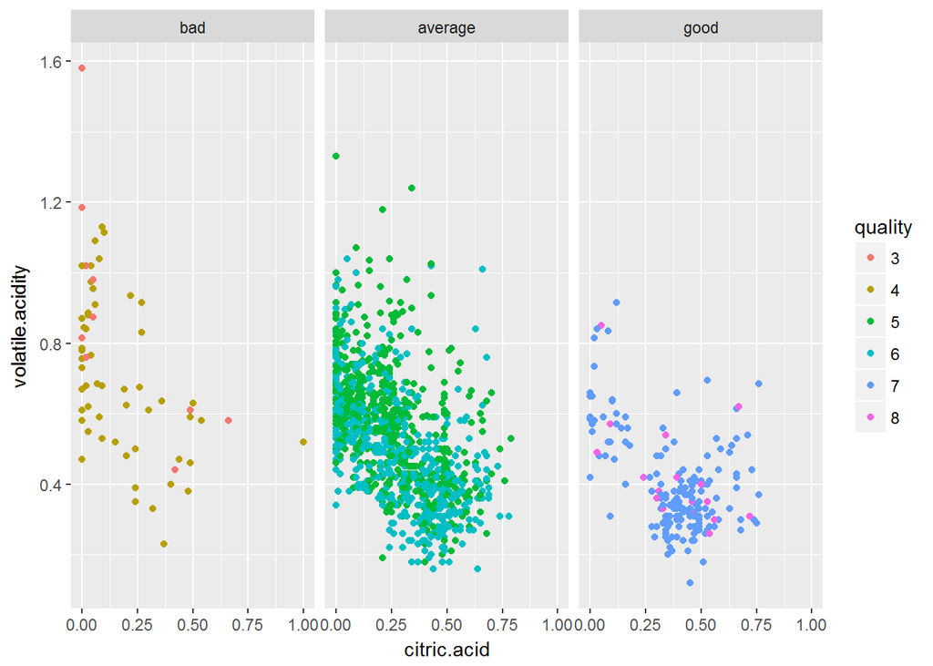

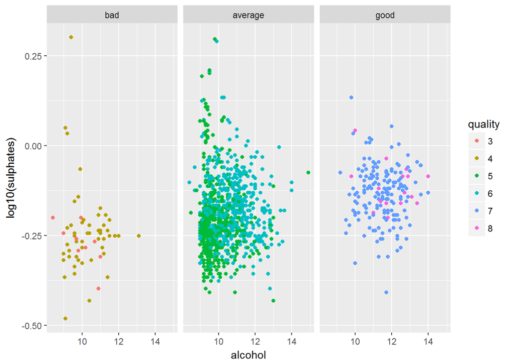

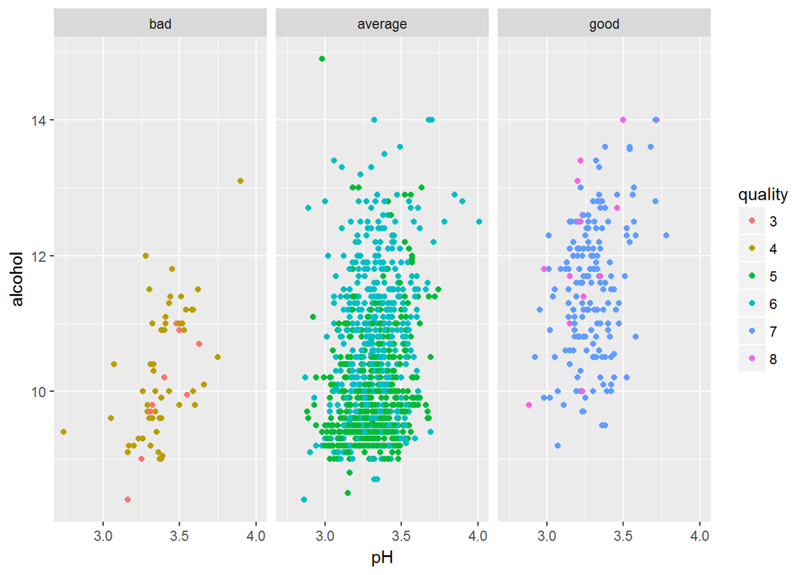

# Multivariate Analysis

I examined the 4 features which showed high correlation with quality. These scatterplots were a bit crowded, so I faceted by rating to illustrate the population differences between good wines, average wines, and bad wines. It’s clear that a higher citric acid and lower volatile (acetic) acid contributes towards better wines.

Better wines tended to have higher sulphates and alcohol content. Surprisingly, pH had very little visual impact on wine quality, and was shadowed by the larger impact of alcohol. Interestingly, this shows that what makes a good wine depends on the type of acids that are present.

### Talk about some of the relationships you observed in this part of the investigation. Were there features that strengthened each other in terms of looking at your feature(s) of interest?

When looking at wine rating, we see a positive relationship between fixed acidity and citric acid.

Better wines tended to have higher sulphates and alcohol content

# Final Plots and Summary

### Plot One: Effect of acids on wine quality

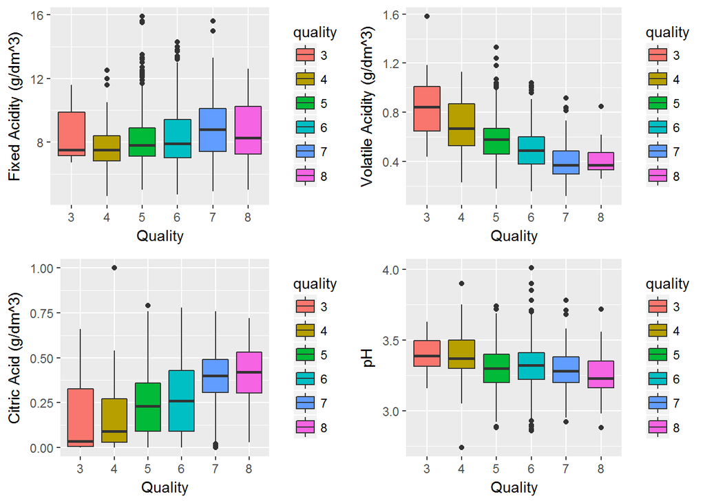

### Description One

These subplots were created to demonstrate the effect of acidity and pH on wine quality. Generally, higher acidity (or lower pH) is seen in highly-rated wines. For a caution , a presence of volatile (acetic) acid negatively affected wine quality. Citric acidity had a high correlation with wine quality, while fixed (tartaric) acid had a smaller impact.

### Plot Two : What makes good wines, good, and bad wines, bad?

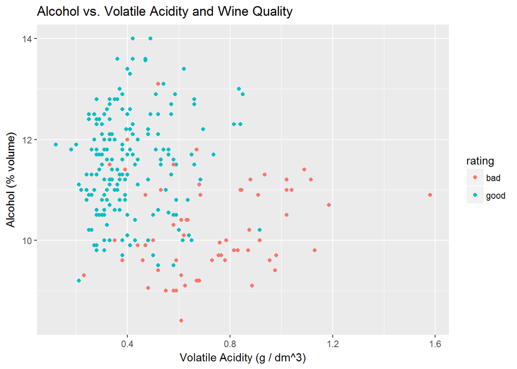

### Description Two

This graph tells us a lot of things. I subsetted the data to remove the ‘average’ wines, or any wine with a rating of 5 or 6. As the correlation tests show, wine quality was affected most strongly by alcohol and volaticle acidity. While the boundaries are not as clear cut or modal, it’s apparent that high volatile acidity–with few exceptions–kept wine quality down. A combination of high alcohol content and low volatile acidity produced better wines.

### Plot three: Alcohol & Sulphates vs. Quality

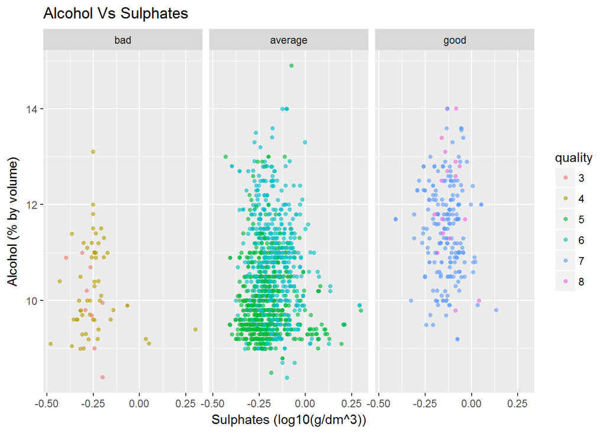

### Description Three

Observe that lower sulphates content typically leads to a bad wine with alcohol varying between 9% and 12%. Average wines have higher concentrations of sulphates, however wines that are rated 6 tend to have higher alcohol content and larger sulphates content. Excellent wines are mostly clustered around higher alcohol contents and higher sulphate contents.

This graph makes it fairly clear that both sulphates and alcohol content contribute to quality. One thing I found fairly interested was that when sulphates were low, alcohol level still varied by 3%, but the wine was still rated bad. Low sulphate content appears to contribute to bad wines.

### Plot four(optional)

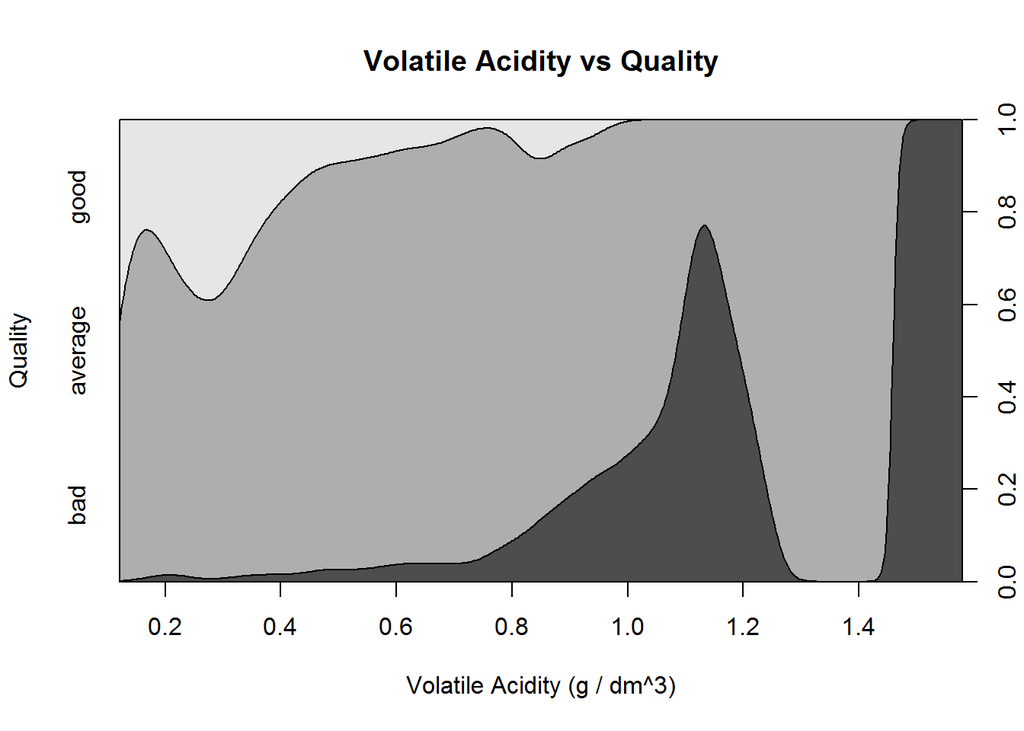

### Description four

# Reflection

The wines data set contains information on 1599 wines across twelve variables from around 2009. I started by understanding the individual variables in the data set, and then I explored interesting questions and leads as I continued to make observations on plots. Eventually, I explored the quality of wines across many variables.

Through this exploratory data analysis, I was able to identify the key factors that determine and drive wine quality, mainly: alcohol content, sulphates, and acidity.

The graphs adequately illustrate the factors that make good wines ‘good’ and bad wines ‘bad’. Further study with inferential statistics could be done to quantitatively confirm these assertions.

There was a trend between the volatile acidity of a wine and its quality. There was also a trend between the alcohol and its quality.

There are very few wines that are rated as low or high quality. We could improve the quality of our analysis by collecting more data, and creating more variables that may contribute to the quality of wine.

My biggest challenge in this exercise was attempting to wrangle a dataset in to a tidy datset. Realizing that this exercise would have taken more time than I had available based on the dataset that I had chosen, I reverted to using one of the recommended datasets for this project.